# **Panorama da inflação**

Os principais índices de inflação do Brasil, apontam em janeiro de 2018 um avanço da inflação de em média **0.43%**. Com esse resultado, no ano a inflação acumula uma variação média positiva de **0.17%**, e em 12 meses uma variação média acumulada de **1.44%**.

|  | Variação mensal | Variação acumulada no ano | Variação acumulada em 12 meses |
| --- | --- | --- | --- |
| IPCA | 0.29% | 0.29% | 2.86% |
| INPC | 0.23% | 0.23% | 1.87% |
| IGP-M | 0.76% | 0% | -0.41% |
| IGP-DI | 0.58% | 0% | -0.28% |
| IPA | 0.58% | 0.01% | -0.02% |
| IPC | 0.69% | 0% | 3.22% |
| INCC | 0.31% | 0% | 4.15% |

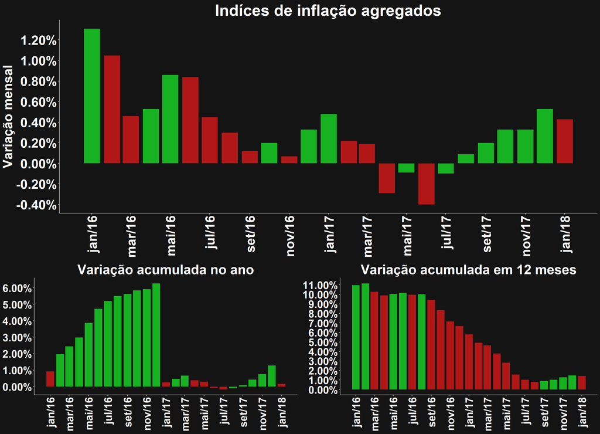

Índices selecionados para a média: IPCA, INPC e IGP-M.

# IPCA

|  | 01/2017 | 12/2017 | 01/2018 |
| --- | --- | --- | --- |
| Variação mensal | 0.38% | 0.44% | 0.29% |
| Variação acumulada no ano | 0.38% | 2.95% | 0.29% |
| Variação acumulada em 12 meses | 5.35% | 2.95% | 2.86% |

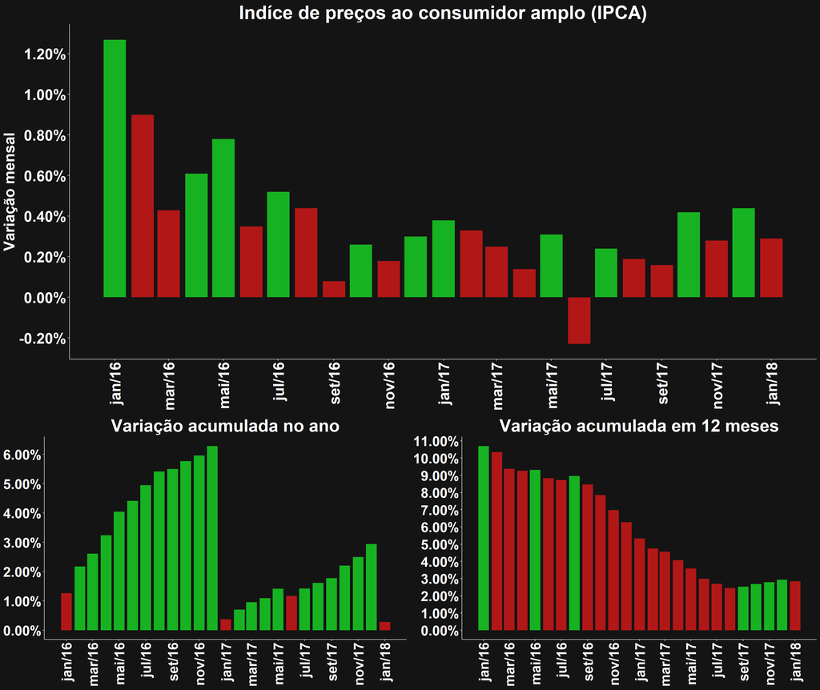

Os grupos que tiveram maior resultado positivo foram Transportes (1.1%) e Alimentação e bebidas (0.74%), e negativo Vestuário (-0.98%) e Habitação (-0.85%).

|  | Variação mensal | Variação acumulada no ano | Peso mensal |
| --- | --- | --- | --- |
| Alimentação e bebidas | 0.74% | 0.74% | 24.58% |
| Habitação | -0.85% | -0.85% | 15.72% |
| Artigos de residência | 0.14% | 0.14% | 3.98% |
| Vestuário | -0.98% | -0.98% | 5.96% |
| Transportes | 1.1% | 1.1% | 18.28% |
| Saúde e cuidados pessoais | 0.42% | 0.42% | 12.04% |
| Despesas pessoais | 0.22% | 0.22% | 10.96% |
| Educação | 0.22% | 0.22% | 4.83% |
| Comunicação | 0.11% | 0.11% | 3.65% |

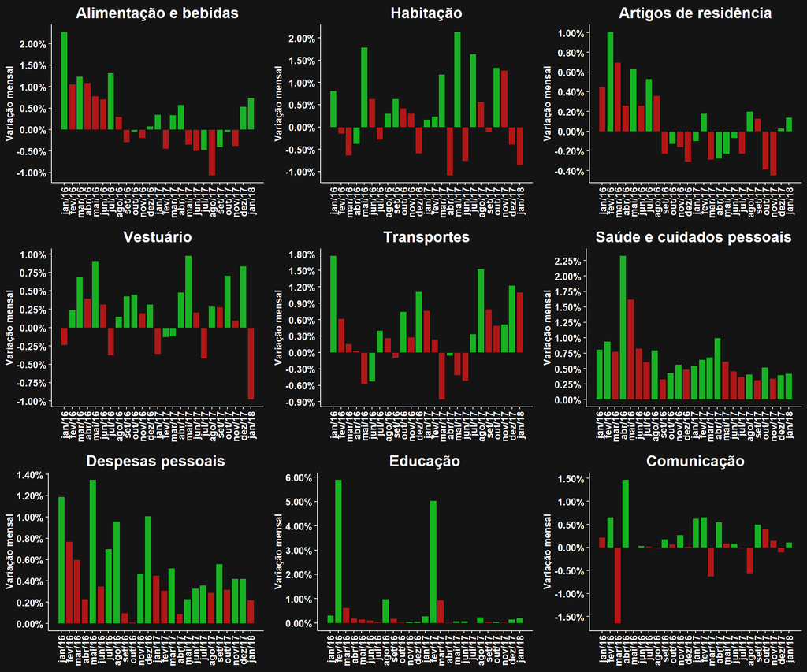

A nível de sub-itens os que mais influenciaram positivamente no resultado em relação ao seu peso foram Gasolina (2.44%%) e Tomate (45.71%%), e negativamente Energia elétrica residencial (-4.73%%) e Conserto de automóvel (-0.74%%).

|  | Variação mensal | Variação acumulada no ano | Peso mensal |
| --- | --- | --- | --- |
| Tomate | 45.71% | 45.71% | 0.18% |
| Gasolina | 2.44% | 2.44% | 4.23% |
| Ônibus urbano | 1.36% | 1.36% | 2.64% |
| Plano de saúde | 1.06% | 1.06% | 3.9% |

|  | Variação mensal | Variação acumulada no ano | Peso mensal |
| --- | --- | --- | --- |
| Conserto de automóvel | -0.74% | -0.74% | 1.73% |
| Camisa/camiseta masculina | -1.48% | -1.48% | 0.62% |
| Energia elétrica residencial | -4.73% | -4.73% | 3.62% |
| Artigos de maquiagem | -5.88% | -5.88% | 0.14% |

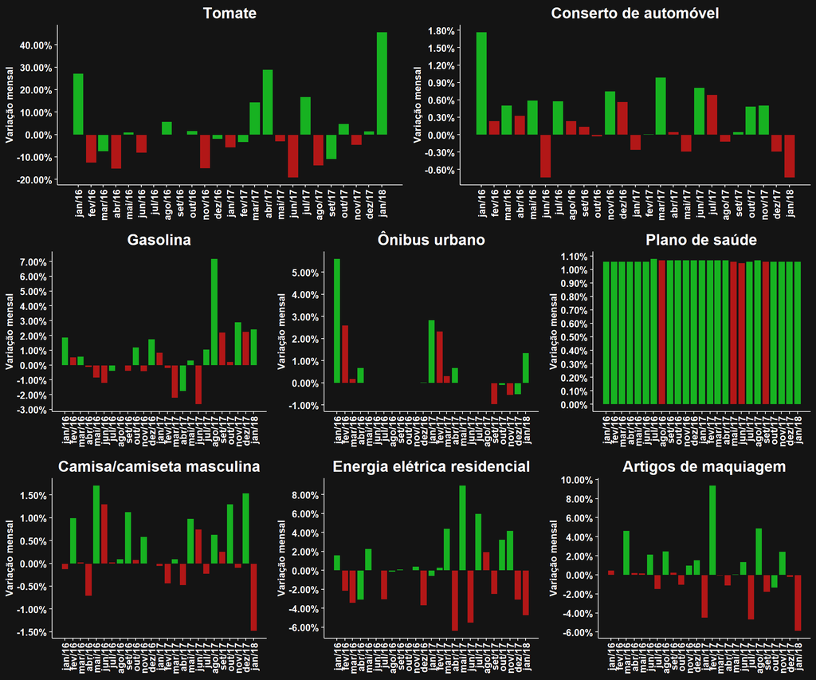

# INPC

|  | 01/2017 | 12/2017 | 01/2018 |
| --- | --- | --- | --- |
| Variação mensal | 0.42% | 0.26% | 0.23% |
| Variação acumulada no ano | 0.42% | 2.07% | 0.23% |
| Variação acumulada em 12 meses | 5.44% | 2.07% | 1.87% |

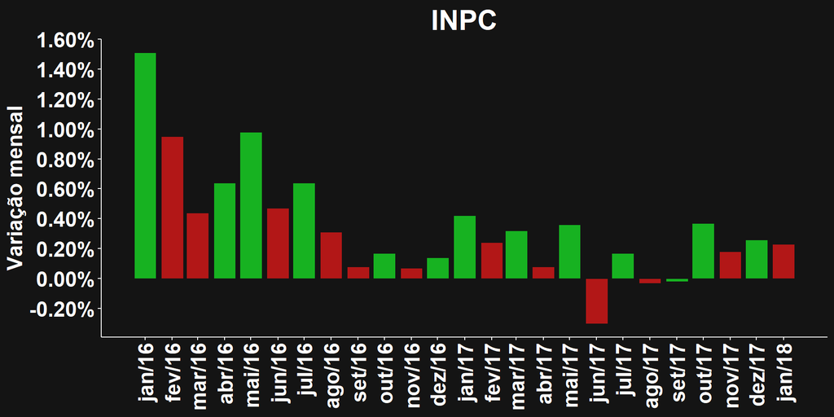

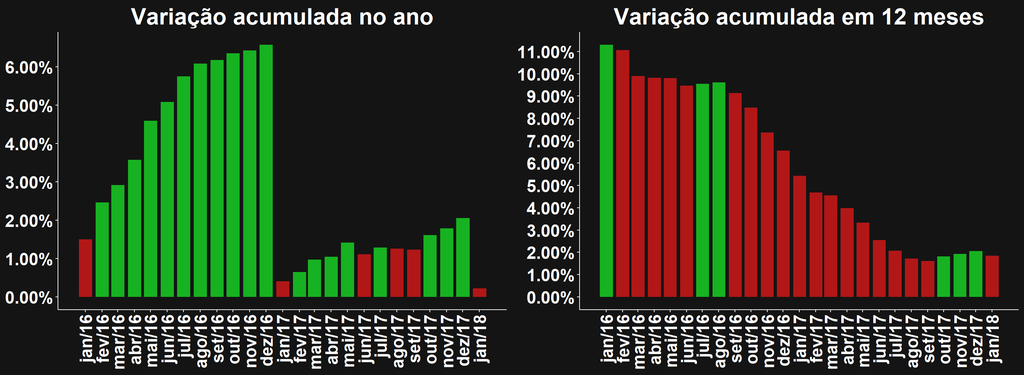

# IGP-M

O Indíce Geral de Preços de Mercado (IGP-M) variou 0.76% em janeiro, valor superior ao mesmo período do ano anterior quando apresentou uma taxa de 0.64%. Com esse resultado o indíce acumula no ano uma variação positiva de 0%, e em 12 meses uma variação negativa de -0.41%.

|  | 01/2017 | 12/2017 | 01/2018 |
| --- | --- | --- | --- |
| Variação mensal | 0.64% | 0.89% | 0.76% |
| Variação acumulada no ano | 0% | -1.15% | 0% |
| Variação acumulada em 12 meses | 6.65% | -0.52% | -0.41% |

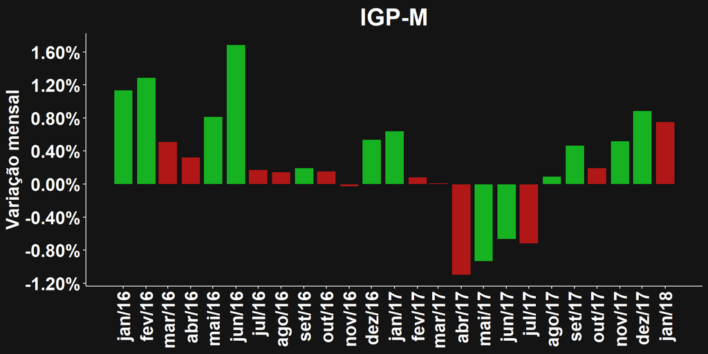

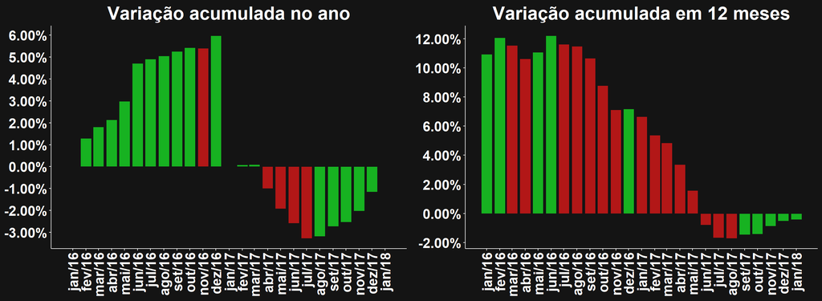

# IGP-DI

O Indíce Geral de Preços - Disponibilidade Interna (IGP-DI) variou 0.58% em janeiro, valor superior ao mesmo período do ano anterior quando apresentou uma taxa de 0.43%. Com esse resultado o indíce acumula no ano uma variação positiva de 0%, e em 12 meses uma variação negativa de -0.28%.

|  | 01/2017 | 12/2017 | 01/2018 |
| --- | --- | --- | --- |
| Variação mensal | 0.43% | 0.74% | 0.58% |
| Variação acumulada no ano | 0% | -0.85% | 0% |
| Variação acumulada em 12 meses | 6.02% | -0.42% | -0.28% |

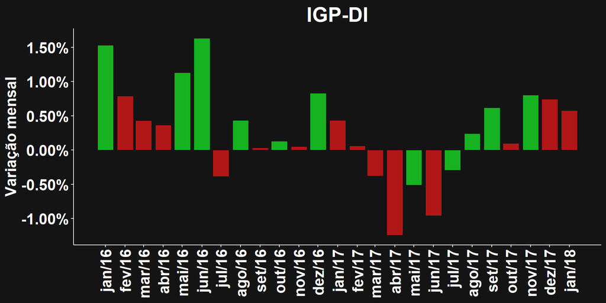

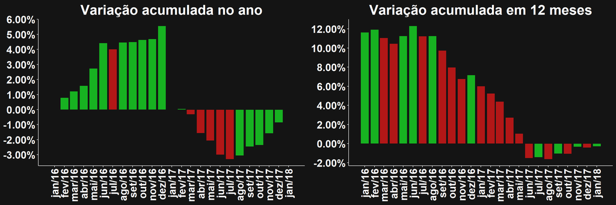

O Indíce de Preços de Atacado (IPA), integrante do IGP-DI com peso de 60%, apresentou variação de 0.58% em janeiro, valor superior ao mesmo período do ano anterior quando apresentou uma taxa de 0.34%. Com esse resultado o indíce acumula no ano uma variação positiva de 0.01%, e em 12 meses uma variação negativa de -0.02%.

|  | 01/2017 | 12/2017 | 01/2018 |
| --- | --- | --- | --- |
| Variação mensal | 0.34% | 1.07% | 0.58% |
| Variação acumulada no ano | 0% | -0.03% | 0.01% |
| Variação acumulada em 12 meses | 0.06% | -0.03% | -0.02% |

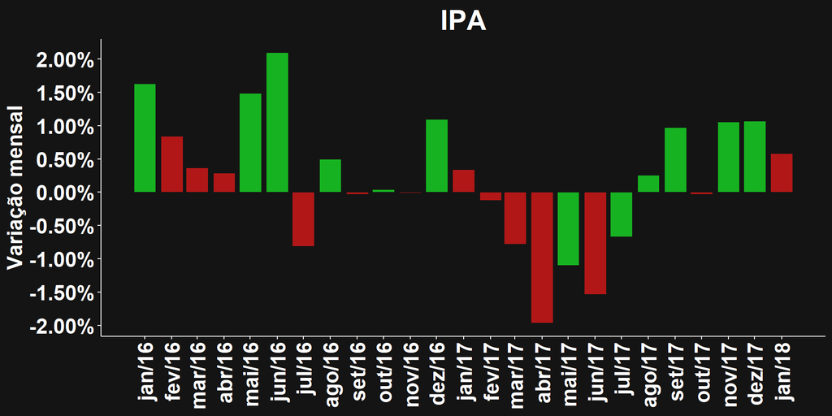

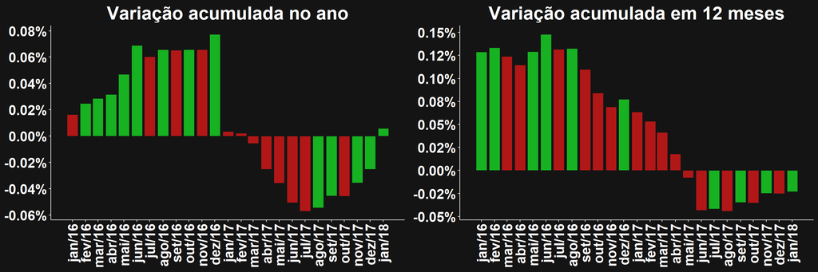

|  | 01/2017 | 12/2017 | 01/2018 |
| --- | --- | --- | --- |
| Variação mensal | 0.69% | 0.21% | 0.69% |
| Variação acumulada no ano | 0% | 2.52% | 0% |
| Variação acumulada em 12 meses | 5.04% | 3.23% | 3.22% |

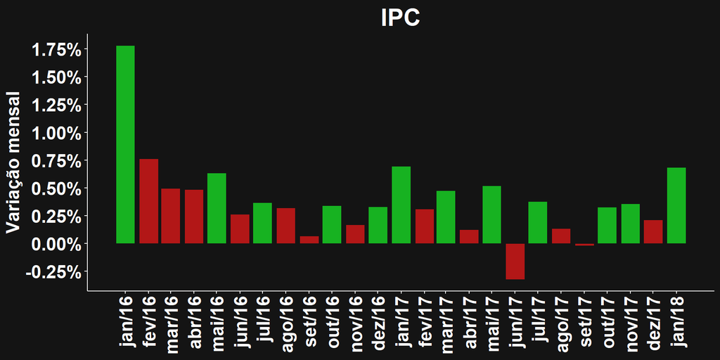

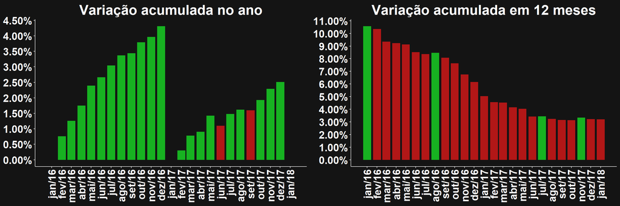

|  | 01/2017 | 12/2017 | 01/2018 |
| --- | --- | --- | --- |
| Variação mensal | 0.41% | 0.07% | 0.31% |
| Variação acumulada no ano | 0% | 3.83% | 0% |
| Variação acumulada em 12 meses | 6.14% | 4.25% | 4.15% |

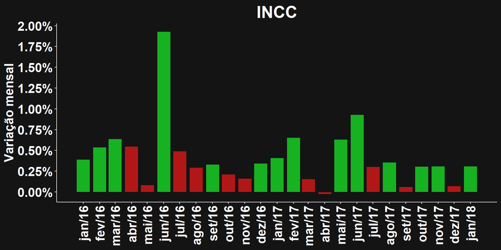

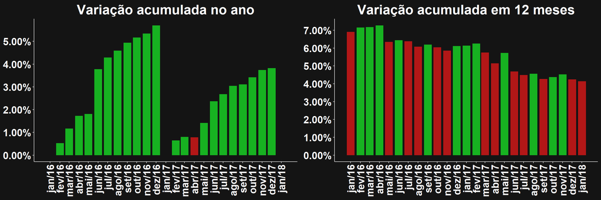

# Estatísticas

As estatísticas descritivas a seguir são feitas com base nos últimos 48 meses, e tem como objetivo possibilitar a avaliação do resultado observado em comparação aos períodos anteriores.

|  | Minimo | 1 Quartil | Mediana | Media | 3 Quartil | Maximo | Desvio Padrão |
| --- | --- | --- | --- | --- | --- | --- | --- |
| IPCA | -0.23% | 0.28% | 0.44% | 0.52% | 0.75% | 1.32% | 0.35% |
| INPC | -0.3% | 0.22% | 0.46% | 0.52% | 0.77% | 1.51% | 0.41% |
| IGP-M | -1.1% | 0.13% | 0.44% | 0.43% | 0.79% | 1.89% | 0.67% |
| IGP-DI | -1.24% | 0.06% | 0.44% | 0.43% | 0.81% | 1.76% | 0.67% |
| IPA | -1.96% | -0.03% | 0.36% | 0.38% | 1.06% | 2.38% | 0.97% |
| IPC | -0.32% | 0.32% | 0.49% | 0.53% | 0.73% | 1.78% | 0.4% |
| INCC | -0.02% | 0.22% | 0.35% | 0.49% | 0.62% | 2.05% | 0.45% |

Levando em consideração o desvio padrão de cada indíce, proporcionalmente os que mais se afastaram da média foram o INPC, o IPCA e o IGP-M.

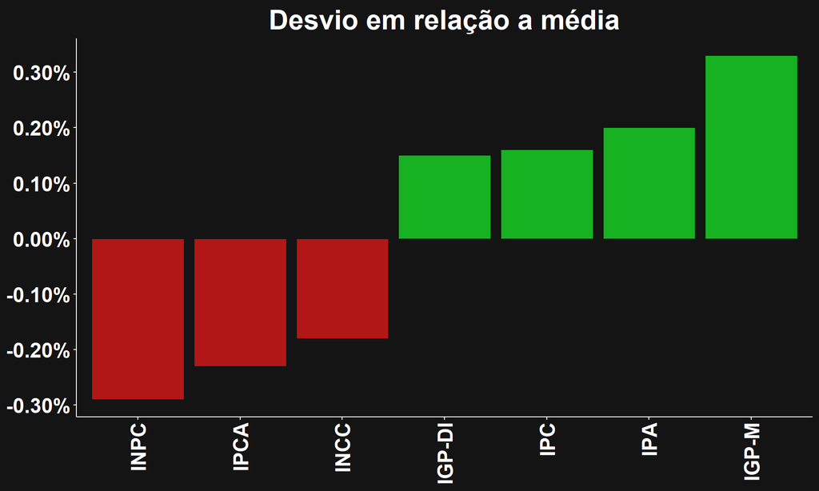

**João Victor Gomes**  
**jvg.santana@gmail.com**  
**[linkedin.com/in/jvictorgomes](https://www.linkedin.com/in/jvictorgomes/)**